# siti_storico_archeologici_italiani

Quante evidenze archeologiche di epoca romana sono presenti in Italia?

Curiosando sul [Catalogo generale dei Beni Culturali](https://catalogo.beniculturali.it/) mi aspettavo di trovare una risposta ma non è stato così. Già solo accedendo al portale, senza applicare nessun tipo di filtro, effettuando uno zoom sull'area dei Campi Flegrei mi ritrovo nella situazione che segue.

[figure not shown]

E' presente il solo [Castello di Baia](https://www.campiflegreionline.it/Castello_di_Baia.html) in questa area, secondo il catalogo, ma nella realtà in quest'area possiamo trovare:

- la [Piscina Mirabilis](https://piscinamirabilisbacoli.it/it)
- la [Casina Vanvitelliana](https://www.prolococittadibacoli.it/casina-vanvitelliana/)
- [Baia sommersa](https://www.baiasommersa.it/)
- il [Tempio di Serapide](http://www.pafleg.it/it/4388/localita/67/macellum-tempio-di-serapide)
- il [Parco archeologico del Pausilypon](https://www.areamarinaprotettagaiola.it/pausilypon)

Solo per citare i luoghi che conosco per averli visitati direttamente, ma ce ne sono tanti altri.

Così ho deciso di usare i superpoteri di Python e [OpenStreetMap](https://www.openstreetmap.org/) per darmi una risposta.

## Prima di iniziare

### Librerie

Per raggiungere l'obiettivo userò le librerie che seguono.

```python
from pathlib import Path
import geopandas as gpd
import pandas as pd
from matplotlib import pyplot as plt
import contextily as cx
import osmnx as ox
```

### Fonti dati

Oltre ai dati di OpenStreetMap userò i confini comunali generalizzati 2023 rilasciati da ISTAT.

```python
main_folder = Path.cwd().parent.parent.parent.parent.joinpath('sample_data')
municipalities = main_folder.joinpath('Com01012023_g').joinpath('Com01012023_g_WGS84.shp')
regions = main_folder.joinpath('Reg01012023_g').joinpath('Reg01012023_g_WGS84.shp')

osm_crs = 4326

municipalities_gdf = gpd.read_file(municipalities).to_crs(osm_crs)
regions_gdf = gpd.read_file(regions).to_crs(osm_crs)
```

Come vedremo in seguito tornerà molto utile conoscere la tassonomia di OpenStreetMap, tassonomia disponibile [qui](https://wiki.openstreetmap.org/wiki/Map_features).

## Rimozione dei warnings

Il codice che segue serve solo per eliminare i messaggi di warning che renderebbero antiestetico l'articolo. **Attenzione ad ignorarli però!** Vanno ben approfonditi e non ignorati alla leggera. Io lo faccio solo perchè questo è un articolo dimostrativo.

```python
import warnings
warnings.filterwarnings('ignore')
warnings.simplefilter('ignore')
```

## Contenuti

- 1. Lavoriamo in piccolo: Bacoli
- 2. Ricerca a scala regionale: Campania
- 3. Ricerca a scala nazionale
- Conclusione

# 1. Lavoriamo in piccolo: Bacoli

Partiremo con l'analizzare l'area di Bacoli.

```python
bacoli = municipalities_gdf[municipalities_gdf['COMUNE']=='Bacoli'].squeeze()
bacoli
```

```
COD_RIP                                                       4
COD_REG                                                      15
COD_PROV                                                     63
COD_CM                                                      263
COD_UTS                                                     263
PRO_COM                                                   63006
PRO_COM_T                                                063006
COMUNE                                                   Bacoli
COMUNE_A                                                    NaN
CC_UTS                                                        0
Shape_Leng                                         20303.054123
geometry      POLYGON ((14.06724657892957 40.842943679557926...
Name: 5138, dtype: object
```

Interrogheremo il database di OpenStreetMap usando [OSMnx](https://osmnx.readthedocs.io/en/stable/index.html) libreria che (cito dal sito del progetto) *is a Python package to download, model, analyze, and visualize street networks and other geospatial features from OpenStreetMap*. Andremo in particolare ad usare il TAG **historic** con alcune eccezioni che vedremo.

```python
%%time

bacoli_data = ox.features_from_polygon(
    polygon=bacoli.geometry,
    tags={'historic': True}
)

bacoli_data
```

```
CPU times: user 266 ms, sys: 3.82 ms, total: 270 ms
Wall time: 734 ms
```

| element_type | osmid | historic | name | wikidata | wikipedia | geometry | tourism | historic:civilization | length | natural | nodes | ... | name:ru | opening_hours | opening_hours:url | operator | phone | reservation | start_date | dataset | description | data |
| --- | --- | --- | --- | --- | --- | --- | --- | --- | --- | --- | --- | --- | --- | --- | --- | --- | --- | --- | --- | --- | --- | --- |
| node | 1045290525 | archaeological_site | Piscina Mirabilis | Q222410 | en:Piscina Mirabilis | POINT (14.08028 40.79519) | NaN | NaN | NaN | NaN | NaN | ... | NaN | NaN | NaN | NaN | NaN | NaN | NaN | NaN | NaN | NaN |
|  | 1104926219 | archaeological_site | Grotte dell'Acqua - Lago Fusaro | NaN | NaN | POINT (14.05955 40.82506) | NaN | NaN | NaN | NaN | NaN | ... | NaN | NaN | NaN | NaN | NaN | NaN | NaN | NaN | NaN | NaN |
|  | 1139094827 | archaeological_site | Grotta della Dragonara | Q55673920 | NaN | POINT (14.08506 40.78477) | attraction | NaN | NaN | NaN | NaN | ... | NaN | NaN | NaN | NaN | NaN | NaN | NaN | NaN | NaN | NaN |
|  | 1139094838 | archaeological_site | Sacello degli Augustali | Q3944423 | it:Sacello degli Augustali | POINT (14.08460 40.78747) | NaN | NaN | NaN | NaN | NaN | ... | NaN | NaN | NaN | NaN | NaN | NaN | NaN | NaN | NaN | NaN |
|  | 1706624371 | archaeological_site | Grotta di Cocceio | Q518104 | NaN | POINT (14.06211 40.84534) | NaN | ancient_roman_-_Augustus_Emperator_period | 1 km | cave_entrance | NaN | ... | NaN | NaN | NaN | NaN | NaN | NaN | NaN | NaN | NaN | NaN |
|  | 2235447677 | ruins | NaN | NaN | NaN | POINT (14.06509 40.82330) | NaN | NaN | NaN | NaN | NaN | ... | NaN | NaN | NaN | NaN | NaN | NaN | NaN | NaN | NaN | NaN |
|  | 2235447711 | memorial | Bunker | NaN | NaN | POINT (14.06457 40.82321) | NaN | NaN | NaN | NaN | NaN | ... | NaN | NaN | NaN | NaN | NaN | NaN | NaN | NaN | NaN | NaN |
|  | 2235447893 | memorial | Bunker | NaN | NaN | POINT (14.06555 40.82358) | NaN | NaN | NaN | NaN | NaN | ... | NaN | NaN | NaN | NaN | NaN | NaN | NaN | NaN | NaN | NaN |
|  | 8755033944 | ruins | Tempo di Iside | NaN | NaN | POINT (14.05002 40.84415) | NaN | NaN | NaN | NaN | NaN | ... | NaN | NaN | NaN | NaN | NaN | NaN | NaN | NaN | NaN | NaN |
|  | 9060732167 | ruins | NaN | NaN | NaN | POINT (14.06845 40.81674) | NaN | NaN | NaN | NaN | NaN | ... | NaN | NaN | NaN | NaN | NaN | NaN | NaN | NaN | NaN | NaN |
| way | 124092891 | archaeological_site | Parco Archeologico Terme di Baia | Q3685188 | it:Complesso archeologico di Baia | POLYGON ((14.07084 40.81923, 14.07072 40.81929... | NaN | ancient_roman | NaN | NaN | [1382052835, 4083235857, 1382052825, 408323585... | ... | NaN | NaN | NaN | NaN | NaN | NaN | NaN | NaN | NaN | NaN |
|  | 124093354 | archaeological_site | Anfiteatro di Cuma | Q93976746 | NaN | POLYGON ((14.05636 40.84248, 14.05598 40.84255... | NaN | ancient_roman | NaN | NaN | [1382055624, 1382055618, 1382055628, 138205562... | ... | NaN | NaN | NaN | NaN | NaN | NaN | NaN | NaN | NaN | NaN |
|  | 144917231 | castle | Castello Aragonese di Baia | Q3662303 | it:Castello Aragonese (Baia) | POLYGON ((14.08025 40.81003, 14.08046 40.81018... | NaN | NaN | NaN | NaN | [1583990045, 1583990048, 1583990061, 158399006... | ... | NaN | NaN | NaN | NaN | NaN | NaN | NaN | NaN | NaN | NaN |
|  | 240100401 | archaeological_site | Tomba di Agrippina | NaN | NaN | POLYGON ((14.08145 40.80291, 14.08133 40.80294... | attraction | NaN | NaN | NaN | [2478723947, 2478723948, 2478723949, 247872395... | ... | NaN | NaN | NaN | NaN | NaN | NaN | NaN | NaN | NaN | NaN |
|  | 323122081 | building | Casina Vanvitelliana | Q958152 | it:Casina Vanvitelliana | POLYGON ((14.05844 40.81979, 14.05847 40.81983... | NaN | NaN | NaN | NaN | [3299164580, 6897303092, 6897328941, 689731239... | ... | Домик Ванвителли | Sa,Su 10:00-14:00,16:00-19:00 | http://www.prolococittadibacoli.it/casina-vanv... | Pro Loco Città di Bacoli | +39 379 1030885 | recommended | 1782 | NaN | NaN | NaN |
|  | 406222066 | archaeological_site | Tempio di Diana | NaN | NaN | POLYGON ((14.07065 40.81926, 14.07043 40.81923... | NaN | NaN | NaN | NaN | [4083235856, 4083235855, 4083235852, 408323584... | ... | NaN | NaN | NaN | NaN | NaN | NaN | NaN | primo quarto del III secolo d.C. | antica aula termale | NaN |
|  | 429218964 | archaeological_site | Columbari | NaN | NaN | POLYGON ((14.06482 40.81952, 14.06543 40.81914... | NaN | NaN | NaN | NaN | [4283467129, 4283467130, 4283467131, 428346713... | ... | NaN | NaN | NaN | NaN | NaN | NaN | NaN | NaN | NaN | NaN |
|  | 429324871 | archaeological_site | Monumental Park of Baia | NaN | NaN | POLYGON ((14.07125 40.81337, 14.07098 40.81320... | NaN | NaN | NaN | NaN | [4284413253, 4284413254, 4284413255, 428441325... | ... | NaN | NaN | NaN | NaN | NaN | NaN | NaN | NaN | NaN | NaN |
|  | 429338160 | archaeological_site | Tempio di Mercurio | NaN | NaN | POLYGON ((14.06978 40.81790, 14.06982 40.81792... | NaN | NaN | NaN | NaN | [4284599234, 4284599235, 4284599236, 428459923... | ... | NaN | NaN | NaN | NaN | NaN | NaN | NaN | NaN | l'edificio era un frigidarium. La volta circol... | prima metà del I sec. d.C. |
|  | 429339087 | archaeological_site | Tempio di Venere | Q96694237 | NaN | POLYGON ((14.07139 40.81624, 14.07152 40.81627... | NaN | NaN | NaN | NaN | [4284611823, 4284611824, 4284611825, 428461182... | ... | NaN | NaN | NaN | NaN | NaN | NaN | NaN | NaN | edificio termale | NaN |
|  | 429340403 | archaeological_site | NaN | NaN | NaN | POLYGON ((14.06974 40.81769, 14.06978 40.81770... | NaN | NaN | NaN | NaN | [4284609514, 4284609515, 4284609516, 428460951... | ... | NaN | NaN | NaN | NaN | NaN | NaN | NaN | NaN | NaN | NaN |
|  | 429341185 | archaeological_site | NaN | NaN | NaN | POLYGON ((14.06991 40.81750, 14.06992 40.81745... | NaN | NaN | NaN | NaN | [4284609519, 4284631813, 4284631814, 428463181... | ... | NaN | NaN | NaN | NaN | NaN | NaN | NaN | NaN | NaN | NaN |
|  | 429341186 | archaeological_site | NaN | NaN | NaN | POLYGON ((14.06997 40.81712, 14.07006 40.81679... | NaN | NaN | NaN | NaN | [4284631827, 4284631828, 4284631829, 428463183... | ... | NaN | NaN | NaN | NaN | NaN | NaN | NaN | NaN | NaN | NaN |
|  | 429341188 | archaeological_site | NaN | NaN | NaN | POLYGON ((14.07011 40.81672, 14.07006 40.81670... | NaN | NaN | NaN | NaN | [4284631843, 4284631844, 4284631845, 428463184... | ... | NaN | NaN | NaN | NaN | NaN | NaN | NaN | NaN | NaN | NaN |
|  | 429341189 | archaeological_site | NaN | NaN | NaN | POLYGON ((14.06979 40.81670, 14.06990 40.81672... | NaN | NaN | NaN | NaN | [4083235569, 4284631859, 4284631860, 428463186... | ... | NaN | NaN | NaN | NaN | NaN | NaN | NaN | NaN | NaN | NaN |
|  | 429341190 | archaeological_site | NaN | NaN | NaN | POLYGON ((14.06992 40.81624, 14.06989 40.81630... | NaN | NaN | NaN | NaN | [4284631863, 4284631864, 4284631865, 906085113... | ... | NaN | NaN | NaN | NaN | NaN | NaN | NaN | NaN | NaN | NaN |
|  | 736686146 | building | NaN | NaN | NaN | POLYGON ((14.07068 40.82155, 14.07062 40.82149... | NaN | NaN | NaN | NaN | [6897279565, 6897310515, 6897272664, 689731985... | ... | NaN | NaN | NaN | NaN | NaN | NaN | NaN | NaN | NaN | NaN |
|  | 736686737 | archaeological_site | NaN | NaN | NaN | POLYGON ((14.06929 40.81767, 14.06939 40.81727... | NaN | NaN | NaN | NaN | [6897334201, 6897298978, 6897296141, 689732206... | ... | NaN | NaN | NaN | NaN | NaN | NaN | NaN | NaN | NaN | NaN |
|  | 736690821 | archaeological_site | NaN | NaN | NaN | POLYGON ((14.06999 40.81713, 14.07037 40.81721... | NaN | NaN | NaN | NaN | [6897281438, 6897326113, 6897290885, 689733550... | ... | NaN | NaN | NaN | NaN | NaN | NaN | NaN | NaN | NaN | NaN |
|  | 1154634667 | archaeological_site | Teatro romano di Misenum | Q55685837 | NaN | POLYGON ((14.08315 40.78788, 14.08303 40.78776... | NaN | ancient_roman | NaN | NaN | [10738232596, 10738232597, 10738232598, 107382... | ... | NaN | NaN | NaN | NaN | NaN | NaN | NaN | NaN | NaN | NaN |

30 rows × 35 columns

```python
bacoli_site_count = len(bacoli_data.index)

bacoli_site_count
```

```
30
```

Come si può vedere in quest'area ci sono ben 30 siti di interesse archeologico, molti più dei tre che conosco che fanno parte dell'elenco di inizio articolo.

Ma veniamo ai TAG di nostro interesse. Analizzando l'elenco delle [chiavi](https://wiki.openstreetmap.org/wiki/Map_features#Historic) ce ne sono alcune che non mi interessano e le inserirò nella viriabile che segue perchè a me interessano solo le strutture o i resti di strutture.

```python
excluded_keys = ['aircraft', 'aircraft; memorial', 'anchor', 'battlefield', 'bomb_crater', 'boundary_stone', 'cannon', 'cattle_crush', 'district', 'highwater_mark', 'hotel', 'locomotive', 'memorial', 'ogham_stone', 'railway', 'railway_car', 'railway_station', 'road', 'shieling', 'ship', 'tank', 'vehicle', 'wayside_cross', 'wayside_shrine', 'wreck', 'yes']

excluded_keys
```

```
['aircraft',
 'aircraft; memorial',
 'anchor',
 'battlefield',
 'bomb_crater',
 'boundary_stone',
 'cannon',
 'cattle_crush',
 'district',
 'highwater_mark',
 'hotel',
 'locomotive',
 'memorial',
 'ogham_stone',
 'railway',
 'railway_car',
 'railway_station',
 'road',
 'shieling',
 'ship',
 'tank',
 'vehicle',
 'wayside_cross',
 'wayside_shrine',
 'wreck',
 'yes']
```

Inoltre escluderò anche alcune colonne dal dataset primario in modo da restringere ulteriormente il campo.

```python
bacoli_data = bacoli_data[['historic', 'name', 'historic:civilization', 'geometry']]
bacoli_data = bacoli_data[~bacoli_data['historic'].isin(excluded_keys)]
bacoli_data = bacoli_data[bacoli_data['name'].notna()]
bacoli_data.reset_index(inplace=True)

bacoli_data
```

|  | element_type | osmid | historic | name | historic:civilization | geometry |
| --- | --- | --- | --- | --- | --- | --- |
| 0 | node | 1045290525 | archaeological_site | Piscina Mirabilis | NaN | POINT (14.08028 40.79519) |
| 1 | node | 1104926219 | archaeological_site | Grotte dell'Acqua - Lago Fusaro | NaN | POINT (14.05955 40.82506) |
| 2 | node | 1139094827 | archaeological_site | Grotta della Dragonara | NaN | POINT (14.08506 40.78477) |
| 3 | node | 1139094838 | archaeological_site | Sacello degli Augustali | NaN | POINT (14.08460 40.78747) |
| 4 | node | 1706624371 | archaeological_site | Grotta di Cocceio | ancient_roman_-_Augustus_Emperator_period | POINT (14.06211 40.84534) |
| 5 | node | 8755033944 | ruins | Tempo di Iside | NaN | POINT (14.05002 40.84415) |
| 6 | way | 124092891 | archaeological_site | Parco Archeologico Terme di Baia | ancient_roman | POLYGON ((14.07084 40.81923, 14.07072 40.81929... |
| 7 | way | 124093354 | archaeological_site | Anfiteatro di Cuma | ancient_roman | POLYGON ((14.05636 40.84248, 14.05598 40.84255... |
| 8 | way | 144917231 | castle | Castello Aragonese di Baia | NaN | POLYGON ((14.08025 40.81003, 14.08046 40.81018... |
| 9 | way | 240100401 | archaeological_site | Tomba di Agrippina | NaN | POLYGON ((14.08145 40.80291, 14.08133 40.80294... |
| 10 | way | 323122081 | building | Casina Vanvitelliana | NaN | POLYGON ((14.05844 40.81979, 14.05847 40.81983... |
| 11 | way | 406222066 | archaeological_site | Tempio di Diana | NaN | POLYGON ((14.07065 40.81926, 14.07043 40.81923... |
| 12 | way | 429218964 | archaeological_site | Columbari | NaN | POLYGON ((14.06482 40.81952, 14.06543 40.81914... |
| 13 | way | 429324871 | archaeological_site | Monumental Park of Baia | NaN | POLYGON ((14.07125 40.81337, 14.07098 40.81320... |
| 14 | way | 429338160 | archaeological_site | Tempio di Mercurio | NaN | POLYGON ((14.06978 40.81790, 14.06982 40.81792... |
| 15 | way | 429339087 | archaeological_site | Tempio di Venere | NaN | POLYGON ((14.07139 40.81624, 14.07152 40.81627... |
| 16 | way | 1154634667 | archaeological_site | Teatro romano di Misenum | ancient_roman | POLYGON ((14.08315 40.78788, 14.08303 40.78776... |

Purtroppo a causa del fatto che la colonna *historic:civilization* non è corrattamente campita non riuscirò a sfruttare correttamente i dati a disposizione per rispondere alla mia domanda iniziale, ma meglio di niente. Alcuni siti come la **Piscina Mirabilis** sono di epoca romana ma questo non viene indicato nella colonna in questione per cui se pure volessi filtrare i dati cercando `roman` con la funzione `str.contains` di [Pandas](https://pandas.pydata.org/docs/reference/api/pandas.Series.str.contains.html?highlight=contains#pandas.Series.str.contains) otterei meno dati del previsto. E' un peccato perchè sotto `Rome` [OpenStreetMap](https://wiki.openstreetmap.org/wiki/Key:historic:civilization#Rome) ha un bel po' di possibilità di ricerca potendo filtrare i dati in base ai vari periodi in cui si è sviluppata la civiltà romana antica.

Come avrete sicuramente notato, il dataset ha geometrie miste. Di seguito lo normalizzerò per fare in modo da avere solo punti.

```python
bacoli_polygons = bacoli_data[bacoli_data['element_type']=='way']

bacoli_polygons
```

|  | element_type | osmid | historic | name | historic:civilization | geometry |
| --- | --- | --- | --- | --- | --- | --- |
| 6 | way | 124092891 | archaeological_site | Parco Archeologico Terme di Baia | ancient_roman | POLYGON ((14.07084 40.81923, 14.07072 40.81929... |
| 7 | way | 124093354 | archaeological_site | Anfiteatro di Cuma | ancient_roman | POLYGON ((14.05636 40.84248, 14.05598 40.84255... |
| 8 | way | 144917231 | castle | Castello Aragonese di Baia | NaN | POLYGON ((14.08025 40.81003, 14.08046 40.81018... |
| 9 | way | 240100401 | archaeological_site | Tomba di Agrippina | NaN | POLYGON ((14.08145 40.80291, 14.08133 40.80294... |
| 10 | way | 323122081 | building | Casina Vanvitelliana | NaN | POLYGON ((14.05844 40.81979, 14.05847 40.81983... |
| 11 | way | 406222066 | archaeological_site | Tempio di Diana | NaN | POLYGON ((14.07065 40.81926, 14.07043 40.81923... |
| 12 | way | 429218964 | archaeological_site | Columbari | NaN | POLYGON ((14.06482 40.81952, 14.06543 40.81914... |
| 13 | way | 429324871 | archaeological_site | Monumental Park of Baia | NaN | POLYGON ((14.07125 40.81337, 14.07098 40.81320... |
| 14 | way | 429338160 | archaeological_site | Tempio di Mercurio | NaN | POLYGON ((14.06978 40.81790, 14.06982 40.81792... |
| 15 | way | 429339087 | archaeological_site | Tempio di Venere | NaN | POLYGON ((14.07139 40.81624, 14.07152 40.81627... |
| 16 | way | 1154634667 | archaeological_site | Teatro romano di Misenum | ancient_roman | POLYGON ((14.08315 40.78788, 14.08303 40.78776... |

```python
bacoli_polygons['centroid'] = bacoli_polygons.geometry.centroid
bacoli_polygons.drop(columns={'geometry'}, inplace=True)
bacoli_polygons.rename(columns={'centroid': 'geometry'}, inplace=True)

bacoli_polygons
```

|  | element_type | osmid | historic | name | historic:civilization | geometry |
| --- | --- | --- | --- | --- | --- | --- |
| 6 | way | 124092891 | archaeological_site | Parco Archeologico Terme di Baia | ancient_roman | POINT (14.07024 40.81724) |
| 7 | way | 124093354 | archaeological_site | Anfiteatro di Cuma | ancient_roman | POINT (14.05604 40.84199) |
| 8 | way | 144917231 | castle | Castello Aragonese di Baia | NaN | POINT (14.08032 40.81106) |
| 9 | way | 240100401 | archaeological_site | Tomba di Agrippina | NaN | POINT (14.08128 40.80285) |
| 10 | way | 323122081 | building | Casina Vanvitelliana | NaN | POINT (14.05842 40.81971) |
| 11 | way | 406222066 | archaeological_site | Tempio di Diana | NaN | POINT (14.07056 40.81914) |
| 12 | way | 429218964 | archaeological_site | Columbari | NaN | POINT (14.06500 40.81928) |
| 13 | way | 429324871 | archaeological_site | Monumental Park of Baia | NaN | POINT (14.07141 40.81283) |
| 14 | way | 429338160 | archaeological_site | Tempio di Mercurio | NaN | POINT (14.06987 40.81782) |
| 15 | way | 429339087 | archaeological_site | Tempio di Venere | NaN | POINT (14.07152 40.81612) |
| 16 | way | 1154634667 | archaeological_site | Teatro romano di Misenum | ancient_roman | POINT (14.08313 40.78778) |

```python
bacoli_final = pd.concat([bacoli_polygons, bacoli_data[bacoli_data['element_type']=='node']])
bacoli_final.drop(columns={'element_type'}, inplace=True)
bacoli_final.sort_values(by='name', inplace=True)
bacoli_final = gpd.GeoDataFrame(bacoli_final, geometry='geometry')

bacoli_final
```

|  | osmid | historic | name | historic:civilization | geometry |
| --- | --- | --- | --- | --- | --- |
| 7 | 124093354 | archaeological_site | Anfiteatro di Cuma | ancient_roman | POINT (14.05604 40.84199) |
| 10 | 323122081 | building | Casina Vanvitelliana | NaN | POINT (14.05842 40.81971) |
| 8 | 144917231 | castle | Castello Aragonese di Baia | NaN | POINT (14.08032 40.81106) |
| 12 | 429218964 | archaeological_site | Columbari | NaN | POINT (14.06500 40.81928) |
| 2 | 1139094827 | archaeological_site | Grotta della Dragonara | NaN | POINT (14.08506 40.78477) |
| 4 | 1706624371 | archaeological_site | Grotta di Cocceio | ancient_roman_-_Augustus_Emperator_period | POINT (14.06211 40.84534) |
| 1 | 1104926219 | archaeological_site | Grotte dell'Acqua - Lago Fusaro | NaN | POINT (14.05955 40.82506) |
| 13 | 429324871 | archaeological_site | Monumental Park of Baia | NaN | POINT (14.07141 40.81283) |
| 6 | 124092891 | archaeological_site | Parco Archeologico Terme di Baia | ancient_roman | POINT (14.07024 40.81724) |
| 0 | 1045290525 | archaeological_site | Piscina Mirabilis | NaN | POINT (14.08028 40.79519) |
| 3 | 1139094838 | archaeological_site | Sacello degli Augustali | NaN | POINT (14.08460 40.78747) |
| 16 | 1154634667 | archaeological_site | Teatro romano di Misenum | ancient_roman | POINT (14.08313 40.78778) |
| 11 | 406222066 | archaeological_site | Tempio di Diana | NaN | POINT (14.07056 40.81914) |
| 14 | 429338160 | archaeological_site | Tempio di Mercurio | NaN | POINT (14.06987 40.81782) |
| 15 | 429339087 | archaeological_site | Tempio di Venere | NaN | POINT (14.07152 40.81612) |
| 5 | 8755033944 | ruins | Tempo di Iside | NaN | POINT (14.05002 40.84415) |
| 9 | 240100401 | archaeological_site | Tomba di Agrippina | NaN | POINT (14.08128 40.80285) |

Ora che il dataset è di soli punti cerchiamo di rispondere a qualche domanda.

## 1.1. Come sono raggruppati i siti?

```python
bacoli_group = bacoli_final.groupby(by='historic').count()
bacoli_group.drop(columns={'name', 'historic:civilization', 'geometry'}, inplace=True)
bacoli_group.rename(columns={'osmid': 'count'}, inplace=True)
bacoli_group.sort_values(by='count', ascending=False, inplace=True)

bacoli_group
```

| historic | count |
| --- | --- |
| archaeological_site | 14 |
| building | 1 |
| castle | 1 |
| ruins | 1 |

## 1.2. Dove sono localizzati i soli siti archeologici?

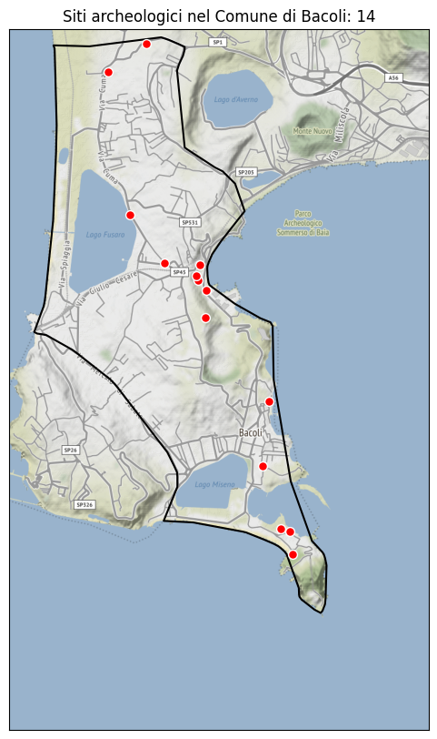

```python
contextily_tile_crs = 3857
target_data = 'archaeological_site'
bacoli_archaeological_site = bacoli_final[bacoli_final['historic']==target_data]

bacoli_polygon = gpd.GeoDataFrame(geometry=gpd.GeoSeries(bacoli.geometry), crs=osm_crs).to_crs(contextily_tile_crs)


b_minx, b_miny, b_maxx, b_maxy = bacoli_polygon.squeeze().bounds

bacoli_img, bacoli_ext = cx.bounds2img(w=b_minx, s=b_miny, e=b_maxx, n=b_maxy, ll=False)

fig, ax = plt.subplots(figsize=(10, 10))
ax.get_xaxis().set_visible(False)
ax.get_yaxis().set_visible(False)
plt.title(f'Siti archeologici nel Comune di Bacoli: {len(bacoli_archaeological_site.index)}')

ax.imshow(bacoli_img, extent=bacoli_ext, zorder=0)
bacoli_polygon.boundary.plot(ax=ax, edgecolor='black', zorder=1)
bacoli_archaeological_site.to_crs(contextily_tile_crs).plot(ax=ax, marker="o", facecolor='red', edgecolor='white', markersize=50, zorder=2)
```

# 2. Ricerca a scala regionale: Campania

Ripetiamo l'analisi ma a scala regionale in modo da ottenere i dati che ci consentiranno di dare le risposte alle stesse domande fatte per Bacoli.

```python
campania = regions_gdf[regions_gdf['DEN_REG']=='Campania'].squeeze()

campania
```

```
COD_RIP                                                       4
COD_REG                                                      15
DEN_REG                                                Campania
Shape_Leng                                         888166.70685
Shape_Area                                   13663252600.799999
geometry      MULTIPOLYGON (((15.294678222474477 40.02369364...
Name: 14, dtype: object
```

```python
%%time

campania_data = ox.features_from_polygon(
    polygon=campania.geometry,
    tags={'historic': True}
)

campania_data
```

```
CPU times: user 6.98 s, sys: 36 ms, total: 7.02 s
Wall time: 15.8 s
```

| element_type | osmid | historic | geometry | name | religion | access | name:bg | name:it | alt_name | archaeological_site | addr:city | ... | old_name | operator:type | disused | pump | defensive | description:de | description:en | disused:railway | hazard | trail_visibility |
| --- | --- | --- | --- | --- | --- | --- | --- | --- | --- | --- | --- | --- | --- | --- | --- | --- | --- | --- | --- | --- | --- | --- |
| node | 1233738646 | ruins | POINT (15.51893 40.07559) | NaN | NaN | NaN | NaN | NaN | NaN | NaN | NaN | ... | NaN | NaN | NaN | NaN | NaN | NaN | NaN | NaN | NaN | NaN |
|  | 1234013962 | castle | POINT (15.55494 40.13962) | NaN | NaN | NaN | NaN | NaN | NaN | NaN | NaN | ... | NaN | NaN | NaN | NaN | NaN | NaN | NaN | NaN | NaN | NaN |
|  | 1278425106 | ruins | POINT (15.42702 40.27348) | NaN | NaN | NaN | NaN | NaN | NaN | NaN | NaN | ... | NaN | NaN | NaN | NaN | NaN | NaN | NaN | NaN | NaN | NaN |
|  | 1456773590 | ruins | POINT (15.36115 39.99905) | Torre dell'Isola | NaN | NaN | NaN | NaN | NaN | NaN | NaN | ... | NaN | NaN | NaN | NaN | NaN | NaN | NaN | NaN | NaN | NaN |
|  | 1601204543 | monument | POINT (15.32197 40.15126) | Chiesa di San Marco Evangelista | NaN | NaN | NaN | NaN | NaN | NaN | NaN | ... | NaN | NaN | NaN | NaN | NaN | NaN | NaN | NaN | NaN | NaN |
| ... | ... | ... | ... | ... | ... | ... | ... | ... | ... | ... | ... | ... | ... | ... | ... | ... | ... | ... | ... | ... | ... | ... |
| way | 1105039541 | ruins | POLYGON ((13.88314 41.12800, 13.88307 41.12790... | NaN | NaN | NaN | NaN | NaN | NaN | NaN | NaN | ... | NaN | NaN | NaN | NaN | NaN | NaN | NaN | NaN | NaN | NaN |
|  | 1109860259 | castle | POLYGON ((14.25132 41.36490, 14.25159 41.36487... | Rupecanina | NaN | NaN | NaN | NaN | NaN | NaN | NaN | ... | NaN | NaN | NaN | NaN | NaN | NaN | NaN | NaN | NaN | NaN |
|  | 1119447938 | building | POLYGON ((14.15338 41.26210, 14.15339 41.26206... | Torre dell'orologio | NaN | NaN | NaN | NaN | NaN | NaN | NaN | ... | NaN | NaN | NaN | NaN | NaN | NaN | NaN | NaN | NaN | NaN |
|  | 1120991526 | building | POLYGON ((14.22349 41.27448, 14.22348 41.27437... | Scuola Municipale Storica di Roccaromana | NaN | NaN | NaN | NaN | NaN | NaN | Roccaromana | ... | NaN | NaN | NaN | NaN | NaN | NaN | NaN | NaN | NaN | NaN |
| relation | 10557325 | castle | POLYGON ((13.93373 41.23848, 13.93372 41.23847... | Castello ducale | NaN | NaN | NaN | NaN | NaN | NaN | NaN | ... | NaN | NaN | NaN | NaN | NaN | NaN | NaN | NaN | NaN | NaN |

3480 rows × 215 columns

```python
campania_data = campania_data[['historic', 'name', 'historic:civilization', 'geometry']]
campania_data = campania_data[~campania_data['historic'].isin(excluded_keys)]
campania_data = campania_data[campania_data['name'].notna()]
campania_data.reset_index(inplace=True)

campania_data
```

|  | element_type | osmid | historic | name | historic:civilization | geometry |
| --- | --- | --- | --- | --- | --- | --- |
| 0 | node | 1456773590 | ruins | Torre dell'Isola | NaN | POINT (15.36115 39.99905) |
| 1 | node | 1601204543 | monument | Chiesa di San Marco Evangelista | NaN | POINT (15.32197 40.15126) |
| 2 | node | 1704137785 | monument | Casa del Canonico Antonio Maria De Luca | NaN | POINT (15.40496 40.09458) |
| 3 | node | 1711457809 | ruins | Cappella S. Michele | NaN | POINT (15.37871 40.09500) |
| 4 | node | 1967471831 | monument | Christo | NaN | POINT (15.35784 40.06201) |
| ... | ... | ... | ... | ... | ... | ... |
| 1803 | way | 1090715537 | ruins | Rovine del Castello di Caianello | NaN | POLYGON ((14.08538 41.29496, 14.08553 41.29500... |
| 1804 | way | 1109860259 | castle | Rupecanina | NaN | POLYGON ((14.25132 41.36490, 14.25159 41.36487... |
| 1805 | way | 1119447938 | building | Torre dell'orologio | NaN | POLYGON ((14.15338 41.26210, 14.15339 41.26206... |
| 1806 | way | 1120991526 | building | Scuola Municipale Storica di Roccaromana | NaN | POLYGON ((14.22349 41.27448, 14.22348 41.27437... |
| 1807 | relation | 10557325 | castle | Castello ducale | NaN | POLYGON ((13.93373 41.23848, 13.93372 41.23847... |

1808 rows × 6 columns

```python
campania_polygons = campania_data[campania_data['element_type']=='way']

campania_polygons
```

|  | element_type | osmid | historic | name | historic:civilization | geometry |
| --- | --- | --- | --- | --- | --- | --- |
| 18 | way | 103970321 | castle | Torre (Castello degli Antichi) | NaN | POLYGON ((15.67241 40.33869, 15.67253 40.33868... |
| 19 | way | 109673812 | castle | Castello di Policastro | NaN | POLYGON ((15.52128 40.07844, 15.52157 40.07790... |
| 20 | way | 111289472 | archaeological_site | Sito archeologico di Molpa | NaN | POLYGON ((15.30344 40.03226, 15.30374 40.03207... |
| 21 | way | 144525571 | castle | Palazzo Baronale | NaN | POLYGON ((15.67943 40.21478, 15.67957 40.21472... |
| 22 | way | 232953215 | building | Palazzo Ducale | NaN | POLYGON ((15.33727 40.33529, 15.33720 40.33496... |
| ... | ... | ... | ... | ... | ... | ... |
| 1802 | way | 1034620667 | ruins | rocca Dragonis | NaN | POLYGON ((13.89958 41.13091, 13.89942 41.13064... |
| 1803 | way | 1090715537 | ruins | Rovine del Castello di Caianello | NaN | POLYGON ((14.08538 41.29496, 14.08553 41.29500... |
| 1804 | way | 1109860259 | castle | Rupecanina | NaN | POLYGON ((14.25132 41.36490, 14.25159 41.36487... |
| 1805 | way | 1119447938 | building | Torre dell'orologio | NaN | POLYGON ((14.15338 41.26210, 14.15339 41.26206... |
| 1806 | way | 1120991526 | building | Scuola Municipale Storica di Roccaromana | NaN | POLYGON ((14.22349 41.27448, 14.22348 41.27437... |

1127 rows × 6 columns

```python
campania_polygons['centroid'] = campania_polygons.geometry.centroid
campania_polygons.drop(columns={'geometry'}, inplace=True)
campania_polygons.rename(columns={'centroid': 'geometry'}, inplace=True)

campania_polygons
```

|  | element_type | osmid | historic | name | historic:civilization | geometry |
| --- | --- | --- | --- | --- | --- | --- |
| 18 | way | 103970321 | castle | Torre (Castello degli Antichi) | NaN | POINT (15.67246 40.33864) |
| 19 | way | 109673812 | castle | Castello di Policastro | NaN | POINT (15.52158 40.07822) |
| 20 | way | 111289472 | archaeological_site | Sito archeologico di Molpa | NaN | POINT (15.30370 40.03271) |
| 21 | way | 144525571 | castle | Palazzo Baronale | NaN | POINT (15.67941 40.21455) |
| 22 | way | 232953215 | building | Palazzo Ducale | NaN | POINT (15.33695 40.33505) |
| ... | ... | ... | ... | ... | ... | ... |
| 1802 | way | 1034620667 | ruins | rocca Dragonis | NaN | POINT (13.89960 41.13073) |
| 1803 | way | 1090715537 | ruins | Rovine del Castello di Caianello | NaN | POINT (14.08543 41.29480) |
| 1804 | way | 1109860259 | castle | Rupecanina | NaN | POINT (14.25164 41.36472) |
| 1805 | way | 1119447938 | building | Torre dell'orologio | NaN | POINT (14.15341 41.26209) |
| 1806 | way | 1120991526 | building | Scuola Municipale Storica di Roccaromana | NaN | POINT (14.22353 41.27442) |

1127 rows × 6 columns

```python
campania_final = pd.concat([campania_polygons, campania_data[campania_data['element_type']=='node']])
campania_final.drop(columns={'element_type'}, inplace=True)
campania_final.sort_values(by='name', inplace=True)
campania_final = gpd.GeoDataFrame(campania_final, geometry='geometry')

campania_final
```

|  | osmid | historic | name | historic:civilization | geometry |
| --- | --- | --- | --- | --- | --- |
| 745 | 2119655941 | monument | 150° Anni d'Italia | NaN | POINT (14.34131 41.07334) |
| 292 | 435717995 | monastery | Abbazia del Goleto | NaN | POINT (15.14352 40.90592) |
| 94 | 4947822441 | ruins | Abitato di acropoli - edificio arcaico | NaN | POINT (15.27648 40.25771) |
| 123 | 222321463 | monument | Acquedotto | NaN | POINT (15.26815 40.24818) |
| 1707 | 845154928 | bridge | Acquedotto | NaN | POINT (14.26074 40.87512) |
| ... | ... | ... | ... | ... | ... |
| 1099 | 505054347 | tomb | unknown tomb | NaN | POINT (14.48051 40.75207) |
| 1097 | 505054345 | tomb | unknown tomb | NaN | POINT (14.48061 40.75202) |
| 433 | 7036790307 | ruins | vecchia calcara | NaN | POINT (14.74056 40.68214) |
| 1703 | 802580354 | archaeological_site | via Domitiana | ancient_roman | POINT (14.05667 40.85108) |
| 1746 | 5378404295 | ruins | villa romana | NaN | POINT (14.21883 41.18651) |

1733 rows × 5 columns

```python
campania_site_count = len(campania_final.index)

campania_site_count
```

```
1733
```

Sulla base dei dati contenuti in OpenStreetMap e dei TAG di ricerca inseriti, risulta che in Campania ci sono 1733 siti di interesse storico-archeologico.

## 2.1. Come sono raggruppati i siti?

```python
campania_group = campania_final.groupby(by='historic').count()
campania_group.drop(columns={'name', 'historic:civilization', 'geometry'}, inplace=True)
campania_group.rename(columns={'osmid': 'count'}, inplace=True)
campania_group.sort_values(by='count', ascending=False, inplace=True)

campania_group
```

| historic | count |
| --- | --- |
| archaeological_site | 577 |
| ruins | 365 |
| monument | 229 |
| castle | 205 |
| tomb | 100 |
| heritage | 78 |
| building | 74 |
| city_gate | 39 |
| citywalls | 11 |
| tower | 10 |
| bridge | 10 |
| church | 9 |
| monastery | 6 |
| fort | 4 |
| farm | 3 |
| aqueduct | 3 |
| roman_road | 2 |
| village | 1 |
| acqueduct | 1 |
| gate | 1 |
| prison | 1 |
| milestone | 1 |
| lavoir | 1 |
| archaelogical_site;mine;aqueduct | 1 |
| windmill | 1 |

## 2.2. Dove sono localizzati i soli siti archeologici?

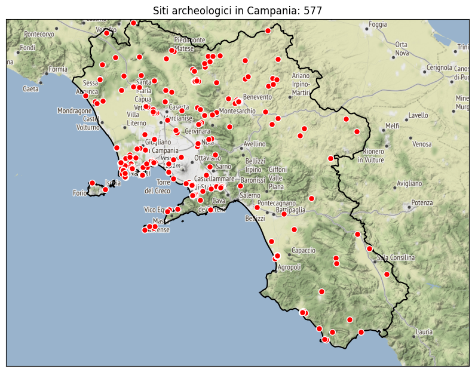

```python
campania_polygon = gpd.GeoDataFrame(geometry=gpd.GeoSeries(campania.geometry), crs=osm_crs).to_crs(contextily_tile_crs)
campania_archaeological_site = campania_final[campania_final['historic']==target_data]

c_minx, c_miny, c_maxx, c_maxy = campania_polygon.squeeze().bounds

campania_img, campania_ext = cx.bounds2img(w=c_minx, s=c_miny, e=c_maxx, n=c_maxy, ll=False)

fig2, ax2 = plt.subplots(figsize=(10, 10))
ax2.get_xaxis().set_visible(False)
ax2.get_yaxis().set_visible(False)
plt.title(f'Siti archeologici in Campania: {len(campania_archaeological_site.index)}')

ax2.imshow(campania_img, extent=campania_ext, zorder=0)
campania_polygon.boundary.plot(ax=ax2, edgecolor='black', zorder=1)
campania_archaeological_site.to_crs(contextily_tile_crs).plot(ax=ax2, marker="o", facecolor='red', edgecolor='white', markersize=50, zorder=2)
```

# 3. Ricerca a scala nazionale

Tutto come al punto *2* ma a scala nazionale.

```python
italia = regions_gdf.dissolve().squeeze()

italia
```

```
geometry      MULTIPOLYGON (((8.41239408066858 38.8612742703...
COD_RIP                                                       1
COD_REG                                                       1
DEN_REG                                                Piemonte
Shape_Leng                                        1236799.83183
Shape_Area                                   25393881930.299999
Name: 0, dtype: object
```

```python
%%time

italia_data = ox.features_from_polygon(
    polygon=italia.geometry,
    tags={'historic': True}
)

italia_data
```

```
CPU times: user 4min 12s, sys: 8.48 s, total: 4min 20s
Wall time: 8min 13s
```

| element_type | osmid | historic | name | geometry | access | barrier | bicycle | foot | motorcar | motorcycle | tourism | ... | lanes:emergency:conditional | bridge:name:fr | name:oc | source:name:oc | source:prominence | name:frp | parking:both | trailblazed:visibility | mtb:note | handrail:left |
| --- | --- | --- | --- | --- | --- | --- | --- | --- | --- | --- | --- | --- | --- | --- | --- | --- | --- | --- | --- | --- | --- | --- |
| node | 7868747286 | memorial | Memoriale vittime del naufragio del 3 ottobre ... | POINT (12.60751 35.50267) | NaN | NaN | NaN | NaN | NaN | NaN | NaN | ... | NaN | NaN | NaN | NaN | NaN | NaN | NaN | NaN | NaN | NaN |
|  | 465242664 | memorial | Monumento all'olivicultore Il Sicano | POINT (12.81015 37.66188) | NaN | NaN | NaN | NaN | NaN | NaN | NaN | ... | NaN | NaN | NaN | NaN | NaN | NaN | NaN | NaN | NaN | NaN |
|  | 910358621 | wayside_cross | NaN | POINT (12.59370 37.66452) | NaN | NaN | NaN | NaN | NaN | NaN | NaN | ... | NaN | NaN | NaN | NaN | NaN | NaN | NaN | NaN | NaN | NaN |
|  | 910561763 | wayside_cross | NaN | POINT (12.60369 37.65963) | NaN | NaN | NaN | NaN | NaN | NaN | NaN | ... | NaN | NaN | NaN | NaN | NaN | NaN | NaN | NaN | NaN | NaN |
|  | 1149564353 | ruins | Torre Granatelli | POINT (12.62953 37.69836) | NaN | NaN | NaN | NaN | NaN | NaN | NaN | ... | NaN | NaN | NaN | NaN | NaN | NaN | NaN | NaN | NaN | NaN |
| ... | ... | ... | ... | ... | ... | ... | ... | ... | ... | ... | ... | ... | ... | ... | ... | ... | ... | ... | ... | ... | ... | ... |
| way | 792170382 | yes | NaN | POLYGON ((6.88599 45.68088, 6.88605 45.68092, ... | NaN | NaN | NaN | NaN | NaN | NaN | NaN | ... | NaN | NaN | NaN | NaN | NaN | NaN | NaN | NaN | NaN | NaN |
|  | 792170989 | yes | NaN | POLYGON ((6.88611 45.68022, 6.88612 45.68026, ... | NaN | NaN | NaN | NaN | NaN | NaN | NaN | ... | NaN | NaN | NaN | NaN | NaN | NaN | NaN | NaN | NaN | NaN |
|  | 889030470 | ruins | NaN | LINESTRING (7.14040 45.68853, 7.14047 45.68853... | NaN | NaN | NaN | NaN | NaN | NaN | NaN | ... | NaN | NaN | NaN | NaN | NaN | NaN | NaN | NaN | NaN | NaN |
|  | 889257442 | wayside_shrine | NaN | POLYGON ((7.13543 45.71861, 7.13546 45.71862, ... | NaN | NaN | NaN | NaN | NaN | NaN | NaN | ... | NaN | NaN | NaN | NaN | NaN | NaN | NaN | NaN | NaN | NaN |
|  | 1080515646 | ruins | Capanna Gamba | POLYGON ((6.88259 45.80152, 6.88264 45.80153, ... | NaN | NaN | NaN | NaN | NaN | NaN | NaN | ... | NaN | NaN | NaN | NaN | NaN | NaN | NaN | NaN | NaN | NaN |

117984 rows × 1254 columns

```python
italia_data = italia_data[['historic', 'name', 'historic:civilization', 'geometry']]
italia_data = italia_data[~italia_data['historic'].isin(excluded_keys)]
italia_data = italia_data[italia_data['name'].notna()]
italia_data.reset_index(inplace=True)

italia_data
```

|  | element_type | osmid | historic | name | historic:civilization | geometry |
| --- | --- | --- | --- | --- | --- | --- |
| 0 | node | 1149564353 | ruins | Torre Granatelli | NaN | POINT (12.62953 37.69836) |
| 1 | node | 1149564682 | ruins | Torre Grimesi | NaN | POINT (12.72536 37.71378) |
| 2 | node | 3878637404 | archaeological_site | Necropoli, Castelvetrano | NaN | POINT (12.78983 37.59280) |
| 3 | node | 4479113496 | ruins | Santuario di Hera Matrimoniale | NaN | POINT (12.81771 37.58643) |
| 4 | node | 5965009778 | archaeological_site | Selinunte ingresso Triscina | Ancient_Greek | POINT (12.81288 37.58463) |
| ... | ... | ... | ... | ... | ... | ... |
| 28114 | way | 445667229 | watermill | Mulino del Grand-Haury | NaN | POLYGON ((7.13874 45.68356, 7.13875 45.68353, ... |
| 28115 | way | 652952909 | ruins | Casermette | modern | POLYGON ((6.90022 45.68080, 6.90025 45.68075, ... |
| 28116 | way | 652952910 | ruins | Casermette | modern | POLYGON ((6.89994 45.68062, 6.89994 45.68056, ... |
| 28117 | way | 768670460 | ruins | Ricovero Adami | NaN | POLYGON ((6.99024 45.61458, 6.99030 45.61462, ... |
| 28118 | way | 1080515646 | ruins | Capanna Gamba | NaN | POLYGON ((6.88259 45.80152, 6.88264 45.80153, ... |

28119 rows × 6 columns

```python
italia_polygons = italia_data[italia_data['element_type']=='way']

italia_polygons
```

|  | element_type | osmid | historic | name | historic:civilization | geometry |
| --- | --- | --- | --- | --- | --- | --- |
| 7 | way | 34943416 | ruins | Arco Normanno | NaN | POLYGON ((12.59113 37.65041, 12.59112 37.65036... |
| 8 | way | 38785368 | ruins | Tempio di Hera | NaN | POLYGON ((12.83445 37.58675, 12.83527 37.58670... |
| 9 | way | 58606782 | ruins | Patrantonio | NaN | POLYGON ((12.65663 37.61588, 12.65687 37.61558... |
| 10 | way | 58606783 | ruins | Baglio Don Federico | NaN | POLYGON ((12.51577 37.69994, 12.51596 37.69984... |
| 11 | way | 58606785 | ruins | Baglio Riolo | NaN | POLYGON ((12.56747 37.67633, 12.56798 37.67623... |
| ... | ... | ... | ... | ... | ... | ... |
| 28114 | way | 445667229 | watermill | Mulino del Grand-Haury | NaN | POLYGON ((7.13874 45.68356, 7.13875 45.68353, ... |
| 28115 | way | 652952909 | ruins | Casermette | modern | POLYGON ((6.90022 45.68080, 6.90025 45.68075, ... |
| 28116 | way | 652952910 | ruins | Casermette | modern | POLYGON ((6.89994 45.68062, 6.89994 45.68056, ... |
| 28117 | way | 768670460 | ruins | Ricovero Adami | NaN | POLYGON ((6.99024 45.61458, 6.99030 45.61462, ... |
| 28118 | way | 1080515646 | ruins | Capanna Gamba | NaN | POLYGON ((6.88259 45.80152, 6.88264 45.80153, ... |

15596 rows × 6 columns

```python
italia_final = pd.concat([italia_polygons, italia_data[italia_data['element_type']=='node']])
italia_final.drop(columns={'element_type'}, inplace=True)
italia_final.sort_values(by='name', inplace=True)
italia_final = gpd.GeoDataFrame(italia_final, geometry='geometry')

italia_final
```

|  | osmid | historic | name | historic:civilization | geometry |
| --- | --- | --- | --- | --- | --- |
| 21854 | 10934220626 | monument | "Abbraccio" di Walter Mutton | NaN | POINT (9.06102 45.69856) |
| 3544 | 5284179170 | monument | "Aia" | NaN | POINT (13.14895 43.50022) |
| 10516 | 4119157392 | monument | "Albero inginocchiato" - luogo in cui San Brun... | NaN | POINT (16.31276 38.55455) |
| 25308 | 6825324511 | archaeological_site | "Campanile" | prehistoric | POINT (8.84725 40.42183) |
| 25671 | 485182848 | ruins | "Ciappa" | NaN | POLYGON ((8.31572 44.16803, 8.31571 44.16802, ... |
| ... | ... | ... | ... | ... | ... |
| 9970 | 2661451129 | archaeological_site | zona archeologica | NaN | POINT (15.95379 37.92615) |
| 9984 | 321561427 | ruins | Àfrico Vecchio | modern | POLYGON ((15.97584 38.06419, 15.97706 38.06399... |
| 4924 | 8344362252 | technical_monument | Áncora di Molo Sartorio | NaN | POINT (13.76053 45.64642) |
| 22775 | 225138405 | ruins | Òsini Betzu/Osini Vecchio | NaN | POLYGON ((9.49217 39.82852, 9.49175 39.82864, ... |
| 5941 | 3548335004 | archaeological_site | Ακράγας | ancient_greek | POINT (13.58857 37.29203) |

26555 rows × 5 columns

```python
italia_site_count = len(italia_final.index)

italia_site_count
```

```
26555
```

## 3.1. Come sono raggruppati i siti?

```python
italia_group = italia_final.groupby(by='historic').count()
italia_group.drop(columns={'name', 'historic:civilization', 'geometry'}, inplace=True)
italia_group.rename(columns={'osmid': 'count'}, inplace=True)
italia_group.sort_values(by='count', ascending=False, inplace=True)

italia_group
```

| historic | count |
| --- | --- |
| archaeological_site | 5472 |
| ruins | 4814 |
| monument | 4024 |
| castle | 3055 |
| building | 1566 |
| ... | ... |
| former_convent | 1 |
| footway | 1 |
| etrusca | 1 |
| edificio_storico_neoclassico | 1 |
| millstone | 1 |

202 rows × 1 columns

## 3.2. Dove sono localizzati i soli siti archeologici?

[figure not shown]

```python
italia_polygon = gpd.GeoDataFrame(geometry=gpd.GeoSeries(italia.geometry), crs=osm_crs).to_crs(contextily_tile_crs)
italia_archaeological_site = italia_final[italia_final['historic']==target_data]

minx, miny, maxx, maxy = italia_polygon.squeeze().bounds

italia_img, italia_ext = cx.bounds2img(w=minx, s=miny, e=maxx, n=maxy, ll=False)

fig3, ax3 = plt.subplots(figsize=(10, 10))
ax3.get_xaxis().set_visible(False)
ax3.get_yaxis().set_visible(False)
plt.title(f'Siti archeologici in Italia: {len(italia_archaeological_site.index)}')

ax3.imshow(italia_img, extent=italia_ext, zorder=0)
italia_polygon.boundary.plot(ax=ax3, edgecolor='black', zorder=1)
italia_archaeological_site.to_crs(contextily_tile_crs).plot(ax=ax3, marker="o", facecolor='red', edgecolor='white', markersize=20, zorder=2)
```

# Conclusione

L'analisi appena condotta può dare solo una stima parziale per patrimonio storico-archeologico italiano. Solo i dati ufficiali del Ministero della Cultura possono dare una informazione esatta. Purtroppo i dati ufficiali al momento risultano molto carenti per cui si fa di necessità virtù. Immaginate cosa potrebbe essere realizzato per incentivare, migliorare ed equamente distribuire il turismo in Italia se i dati ufficiali fossero liberamente disponibili. Le metodologie di analisi, come quella appena condotta, esistono ma manca il dato! Manca il dato OPEN!